# 03_modeling_creation

Aidan Coyle

5/24/2021

In this script, we will be creating our models, along with giving some brief explanations for the choices made, and evaluating the created models

First, read in our data and load all necessary libraries

```r
# Add all required libraries here
list.of.packages <- c("tidyverse", "lme4", "MuMIn", "rcompanion", "MASS", "viridis", "generalhoslem", "mgcv")
# Get names of all required packages that aren't installed
new.packages <- list.of.packages[!(list.of.packages %in% installed.packages()[, "Package"])]
# Install all new packages
if(length(new.packages)) install.packages(new.packages)


# Load all required libraries
lapply(list.of.packages, FUN = function(X) {
  do.call("require", list(X))
})
```

```
## [[1]]
## [1] TRUE
##
## [[2]]
## [1] TRUE
##
## [[3]]
## [1] TRUE
##
## [[4]]
## [1] TRUE
##
## [[5]]
## [1] TRUE
##
## [[6]]
## [1] TRUE
##
## [[7]]
## [1] TRUE
##
## [[8]]
## [1] TRUE
```

```r
# Load in our data file created in the previous script
crabdat <- read.csv("../output/crab_data_tables/allyears_cleaned.csv")
```

Now, let’s review our model. We have a Bernoulli distribution, plus random effects, so we’ll be making a generalized linear mixed model (or GLMM).

Before doing anything else, we’ll ensure all our variables were read in correctly (as either categorical or continuous predictors)

```r
# See class of each column
str(crabdat)
```

```
## 'data.frame':    14486 obs. of  10 variables:
##  $ YEAR                : int  2007 2007 2007 2007 2007 2007 2007 2007 2007 2007 ...
##  $ LOCATION_CODE       : int  1 1 1 1 1 1 1 1 1 1 ...
##  $ DEPTH_FATHOMS       : int  36 36 36 36 36 36 36 36 36 36 ...
##  $ SEX_CODE            : chr  "M" "M" "M" "M" ...
##  $ WIDTH_MILLIMETERS   : int  108 133 99 112 103 131 147 152 135 109 ...
##  $ SHELL_CONDITION_CODE: int  3 3 3 3 3 3 3 4 3 3 ...
##  $ BLACKMAT_CODE       : int  0 0 0 0 0 0 0 0 0 0 ...
##  $ PARASITE_CODE       : int  0 0 0 0 0 0 1 0 1 0 ...
##  $ LEG_CONDITION_CODE  : int  0 0 0 0 1 0 0 1 0 0 ...
##  $ JUL_DAY             : int  278 278 278 278 278 278 278 278 278 278 ...
```

```r
# Looks like we've got lots of columns that should be converted to factors!
crabdat$LOCATION_CODE <- factor(crabdat$LOCATION_CODE)
crabdat$SEX_CODE <- ordered(crabdat$SEX_CODE,
                            levels = c("M", "F"))
crabdat$SHELL_CONDITION_CODE <- ordered(crabdat$SHELL_CONDITION_CODE)
crabdat$BLACKMAT_CODE <- ordered(crabdat$BLACKMAT_CODE)
crabdat$PARASITE_CODE <- ordered(crabdat$PARASITE_CODE)
crabdat$LEG_CONDITION_CODE <- ordered(crabdat$LEG_CONDITION_CODE)
```

### Check for correlation

Prior to modeling anything, we’re going to run checks on combinations of variables to see if any are correlated

```r
# CORRELATION BETWEEN CONTINUOUS VARIABLES

crabnums <- select_if(crabdat, is.numeric)
numcor <- cor(crabnums, method = "pearson")

# See the resulting table
print(numcor)
```

```
##                          YEAR DEPTH_FATHOMS WIDTH_MILLIMETERS     JUL_DAY
## YEAR               1.00000000   -0.09324407        0.09543995 -0.05539855
## DEPTH_FATHOMS     -0.09324407    1.00000000       -0.08946356  0.42133708
## WIDTH_MILLIMETERS  0.09543995   -0.08946356        1.00000000 -0.15857952
## JUL_DAY           -0.05539855    0.42133708       -0.15857952  1.00000000
```

```r
# See if any correlations are > 0.6 (our bar for correlation) and less than 1 (since every variable is perfectly correlated with itself)
any(abs(numcor) > 0.6 & numcor < 1)
```

```
## [1] FALSE
```

```r
# Looks like none are above our bar!

# CORRELATIONS BETWEEN CATEGORICAL VARIABLES

# Now we're using Cramer's V test to look at correlation among our categorical variables
crabcat <- select_if(crabdat, is.factor)

# Turn all from factors to numeric
crabcat[] <- sapply(crabcat, as.numeric)

# Initialize a blank matrix
results_matrix <- matrix(nrow = length(crabcat), ncol = length(crabcat))
# Name all rows and columns with our variable names
colnames(results_matrix) <- names(crabcat)
rownames(results_matrix) <- names(crabcat)

# Fill the matrix by performing Cramer's V test on each possible combination of factors
for (i in 1:ncol(crabcat)) {
  for (j in 1:ncol(crabcat)) {
    cramer.table <- table(crabcat[,i],crabcat[,j])
    cramer.matrix <- as.matrix(cramer.table)
    results_matrix[i,j] <- cramerV(cramer.matrix)
  }
}
# See the resulting matrix
print(results_matrix)
```

```
##                      LOCATION_CODE SEX_CODE SHELL_CONDITION_CODE BLACKMAT_CODE
## LOCATION_CODE               1.0000  0.17860               0.1792       0.30740
## SEX_CODE                    0.1786  1.00000               0.3233       0.09583
## SHELL_CONDITION_CODE        0.1792  0.32330               1.0000       0.24030
## BLACKMAT_CODE               0.3074  0.09583               0.2403       1.00000
## PARASITE_CODE               0.3117  0.07045               0.2340       0.08117
## LEG_CONDITION_CODE          0.1032  0.04562               0.1742       0.07371
##                      PARASITE_CODE LEG_CONDITION_CODE
## LOCATION_CODE              0.31170            0.10320
## SEX_CODE                   0.07045            0.04562
## SHELL_CONDITION_CODE       0.23400            0.17420
## BLACKMAT_CODE              0.08117            0.07371
## PARASITE_CODE              1.00000            0.03936
## LEG_CONDITION_CODE         0.03936            1.00000
```

```r
# See if any of our correlations (aside from self-correlations) cross our boundary of too much correlation
any(results_matrix > 0.6 & results_matrix < 1)
```

```
## [1] FALSE
```

```r
# Looks like none are above our bar

# CORRELATIONS BETWEEN CATEGORICAL AND CONTINUOUS VARIABLES

# We'll use Spearman rank-order correlation to determine whether we have any correlation
crabrank <- crabdat
crabrank[] <- sapply(crabdat, as.numeric)
crabcomps <- cor(crabrank, method = "spearman")
any(abs(crabcomps) > 0.6 & crabcomps < 1)
```

```
## [1] TRUE
```

```r
# Looks like we do have some significant correlations this time! Let's pull them out
which(abs(crabcomps) > 0.6 & crabcomps < 1, arr.ind = TRUE)
```

```
##                   row col
## WIDTH_MILLIMETERS   5   4
## SEX_CODE            4   5
```

```r
names(crabdat)[c(5,4)]
```

```
## [1] "WIDTH_MILLIMETERS" "SEX_CODE"
```

Looks like sex and carapace width are correlated! Therefore, we should only put one of these into our model. All other variables don’t show sufficient correlation to cause problems.

### Scaling variables

We also need to scale some of our predictors to allow the model to fit more easily

```r
# Subtract the year before the earliest data from our survey, so year now starts at 1
crabdat$s.YEAR <- crabdat$YEAR-(min(crabdat$YEAR)-1)
# Scale depth, carapace width, and Julian day
crabdat$DEPTH_SCALED <- scale(crabdat$DEPTH_FATHOMS)
crabdat$WIDTH_SCALED <- scale(crabdat$WIDTH_MILLIMETERS)
crabdat$DAY_SCALED <- scale(crabdat$JUL_DAY)
```

## Modeling

#### Determining What Variables to Include using Laplace Approximation

Our full model is too large to directly run. To determine what variables to include in our full model, we will make a Laplace Approximation model with each variable individually plus the random effects, and then compare that to a null model that contains just the random effects. Then we will use AIC to determine whether the variable improves the model over the null model. If so, we will include it in the full model.

```r
# Create null model and get AIC
null_mod <- glmer(PARASITE_CODE ~ (1 | LOCATION_CODE) + (1 | s.YEAR),
                  data = crabdat,
                  family = binomial)
AIC_null <- extractAIC(null_mod)[2]
print(AIC_null)
```

```
## [1] 9119.41
```

```r
# Create model with only Black Mat code
blackmat_mod <- glmer(PARASITE_CODE ~ BLACKMAT_CODE + (1 | LOCATION_CODE) + (1 | s.YEAR),
                      data = crabdat,
                      family = binomial)
extractAIC(blackmat_mod)
```

```
## [1]    4.000 9045.583
```

```r
extractAIC(blackmat_mod)[2] < AIC_null
```

```
## [1] TRUE
```

```r
AIC_null - extractAIC(blackmat_mod)[2]
```

```
## [1] 73.82657
```

```r
# Looks like Black Mat improves the model!

depth_mod <- glmer(PARASITE_CODE ~ DEPTH_SCALED + (1 | LOCATION_CODE) + (1 | s.YEAR),
                      data = crabdat,
                      family = binomial)
extractAIC(depth_mod)
```

```
## [1]    4.000 9089.927
```

```r
extractAIC(depth_mod) < AIC_null
```

```
## [1] TRUE TRUE
```

```r
AIC_null - extractAIC(depth_mod)[2]
```

```
## [1] 29.48233
```

```r
# Looks like depth also improves the model!

shellcond_mod <- glmer(PARASITE_CODE ~ SHELL_CONDITION_CODE + (1 | LOCATION_CODE) + (1 | s.YEAR),
                      data = crabdat,
                      family = binomial)
extractAIC(shellcond_mod)
```

```
## [1]    6.000 8327.564
```

```r
extractAIC(shellcond_mod) < AIC_null
```

```
## [1] TRUE TRUE
```

```r
AIC_null - extractAIC(shellcond_mod)[2]
```

```
## [1] 791.8453
```

```r
# Shell condition also improves the model!

day_mod <- glmer(PARASITE_CODE ~ DAY_SCALED + (1 | LOCATION_CODE) + (1 | s.YEAR),
                      data = crabdat,
                      family = binomial)
extractAIC(day_mod)
```

```
## [1]    4.000 9116.093
```

```r
extractAIC(day_mod) < AIC_null
```

```
## [1] TRUE TRUE
```

```r
AIC_null - extractAIC(day_mod)[2]
```

```
## [1] 3.316886
```

```r
# Day also improves the model (though just barely)

CW_mod <- glmer(PARASITE_CODE ~ WIDTH_SCALED + (1 | LOCATION_CODE) + (1 | s.YEAR),
                      data = crabdat,
                      family = binomial)
extractAIC(CW_mod)
```

```
## [1]    4.000 9015.216
```

```r
extractAIC(CW_mod) < AIC_null
```

```
## [1] TRUE TRUE
```

```r
AIC_null - extractAIC(CW_mod)[2]
```

```
## [1] 104.1937
```

```r
# Carapace width also improves the model

sex_mod <- glmer(PARASITE_CODE ~ SEX_CODE + (1 | LOCATION_CODE) + (1 | s.YEAR),
                      data = crabdat,
                      family = binomial)
extractAIC(sex_mod)
```

```
## [1]    4.000 9100.004
```

```r
extractAIC(sex_mod) < AIC_null
```

```
## [1] TRUE TRUE
```

```r
AIC_null - extractAIC(sex_mod)[2]
```

```
## [1] 19.40554
```

```r
legcond_mod <- glmer(PARASITE_CODE ~ LEG_CONDITION_CODE + (1 | LOCATION_CODE) + (1 | s.YEAR),
                      data = crabdat,
                      family = binomial)
extractAIC(legcond_mod)
```

```
## [1]    4.000 9110.624
```

```r
extractAIC(legcond_mod) < AIC_null
```

```
## [1] TRUE TRUE
```

```r
AIC_null - extractAIC(legcond_mod)[2]
```

```
## [1] 8.785319
```

```r
# Well shoot, leg condition also improves over the null model
```

#### Laplace Approximation

One difficulty with Laplace approximation is that it is slower and more computationally intensive. We have a very complex model, which, in fact, makes it impossible to run our full model immediately. As a result, instead we plan to create a smaller model and then slowly build on it using the update() function

```r
# Start by building small model with 2 fixed effects + our random effects. We will choose blackmat code and shell condition, since they had the strongest effect on our PQL model
lap_first_mod <- glmer(PARASITE_CODE ~ BLACKMAT_CODE + SHELL_CONDITION_CODE + (1 | LOCATION_CODE) + (1 | s.YEAR),
                       data = crabdat,
                       family = binomial,
                       na.action = "na.fail",   # This chunk is for the dredge() function used later
                       control = glmerControl(optimizer = c("bobyqa"))) # This is to improve optimization

#Next, update the model to include the effects of depth
lap_two_mod <- update(lap_first_mod, PARASITE_CODE ~ BLACKMAT_CODE + SHELL_CONDITION_CODE + DEPTH_SCALED + (1 | LOCATION_CODE) + (1 | s.YEAR))

# Next, update the model to include the effects of day
lap_three_mod <- update(lap_two_mod, PARASITE_CODE ~ BLACKMAT_CODE + SHELL_CONDITION_CODE  + DEPTH_SCALED  + DAY_SCALED + (1 | LOCATION_CODE) + (1 | s.YEAR))

# Now, we'll update with our correlated variables. One of the models will include sex, and the other will include carapace width. We're adding our correlated variables followed by leg condition rather than adding leg condition first because doing the reverse simply won't run.

lap_sex_mod <- update(lap_three_mod, PARASITE_CODE ~ BLACKMAT_CODE + SHELL_CONDITION_CODE +  DEPTH_SCALED + DAY_SCALED + SEX_CODE + (1 | LOCATION_CODE) + (1 | s.YEAR))

lap_sexlegs_mod <- update(lap_sex_mod, PARASITE_CODE ~ BLACKMAT_CODE + SHELL_CONDITION_CODE +  DEPTH_SCALED + DAY_SCALED + SEX_CODE + LEG_CONDITION_CODE + (1 | LOCATION_CODE) + (1 | s.YEAR))

lap_CW_mod <- update(lap_three_mod, PARASITE_CODE ~ BLACKMAT_CODE + SHELL_CONDITION_CODE + DEPTH_SCALED + DAY_SCALED + WIDTH_SCALED + (1 | LOCATION_CODE) + (1 | s.YEAR))

lap_CWlegs_mod <- update(lap_CW_mod, PARASITE_CODE ~ BLACKMAT_CODE + SHELL_CONDITION_CODE + DEPTH_SCALED + DAY_SCALED + WIDTH_SCALED + LEG_CONDITION_CODE + (1 | LOCATION_CODE) + (1 | s.YEAR))
```

[output not shown]

[output not shown]

### Dredging

We will now use the dredge() function from the MuMIn package to go through each of our model possibilities and select an optimal full model using AIC.

```r
# First, extract AIC of our two full models
extractAIC(lap_sexlegs_mod)
```

```
## [1]   11.000 8214.575
```

```r
extractAIC(lap_CWlegs_mod)
```

```
## [1]   11.000 8179.866
```

```r
# Also extract AIC of our near-full models that exclude leg condition, since it causes problems when trying to use dredge()
extractAIC(lap_sex_mod)
```

```
## [1]   10.000 8212.789
```

```r
extractAIC(lap_CW_mod)
```

```
## [1]   10.000 8177.869
```

```r
# Of these, it looks like models that include CW are much better than models that include sex. Therefore, the best of our two full models is lap_CWlegs_mod, which includes all variables except sex.

# However, when trying to run dredge() on lap_CWlegs_mod, a very large number of the models fail to converge, returning "unable to evaluate scaled gradientModel failed to converge: degenerate  Hessian with 1 negative eigenvalues variance-covariance matrix computed from finite-difference Hessian is not positive definite or contains NA values: falling back to var-cov estimated from RXvariance-covariance matrix computed from finit"

# Therefore, we are forced to choose a "full" model that actually runs. Excluding Julian day does nothing to help it run, but excluding leg condition does let it run. Therefore, we will treat our new "full" model as one which includes all variables but sex and leg condition.

# Use the dredge() function to generate a model selection table with various combinations of fixed effect terms
lap_mods <- dredge(lap_CW_mod, beta = "none",
       eval = TRUE,
       rank = "AICc")
```

```
## Fixed term is "(Intercept)"
```

```r
# See all the resulting models
lap_mods
```

```
## Global model call: glmer(formula = PARASITE_CODE ~ BLACKMAT_CODE + SHELL_CONDITION_CODE +
##     DEPTH_SCALED + DAY_SCALED + WIDTH_SCALED + (1 | LOCATION_CODE) +
##     (1 | s.YEAR), data = crabdat, family = binomial, control = glmerControl(optimizer = c("bobyqa")),
##     na.action = "na.fail")
## ---
## Model selection table
##      (Int) BLA_COD  DAY_SCA DEP_SCA SHE_CON_COD WID_SCA df    logLik   AICc
## 30 -10.660       +          -0.5096           +  0.2072  9 -4079.003 8176.0
## 32 -10.660       + -0.03453 -0.5070           +  0.2069 10 -4078.935 8177.9
## 29  -3.543                  -0.5164           +  0.2107  8 -4090.433 8196.9
## 31  -3.539         -0.03616 -0.5136           +  0.2104  9 -4090.358 8198.7
## 14 -10.660       +          -0.4764           +          8 -4101.461 8218.9
## 16 -10.650       + -0.05770 -0.4723           +          9 -4101.274 8220.6
## 13  -3.510                  -0.4826           +          7 -4113.662 8241.3
## 15  -3.502         -0.05968 -0.4784           +          8 -4113.461 8242.9
```

[output cut: 60 more lines]

```r
# Looks like only two of our models have weights > 0! Let's look at them:
best_two <- get.models(lap_mods, subset = weight > 0.01)

# First model - heaviest weight, at 0.72
first_mod <- best_two[[1]]
first_mod
```

```
## Generalized linear mixed model fit by maximum likelihood (Laplace
##   Approximation) [glmerMod]
##  Family: binomial  ( logit )
## Formula: PARASITE_CODE ~ BLACKMAT_CODE + DEPTH_SCALED + SHELL_CONDITION_CODE +
##     WIDTH_SCALED + (1 | LOCATION_CODE) + (1 | s.YEAR)
##    Data: crabdat
##       AIC       BIC    logLik  deviance  df.resid
##  8176.006  8244.235 -4079.003  8158.006     14477
## Random effects:
##  Groups        Name        Std.Dev.
##  LOCATION_CODE (Intercept) 0.8817
##  s.YEAR        (Intercept) 0.2127
## Number of obs: 14486, groups:  LOCATION_CODE, 13; s.YEAR, 6
## Fixed Effects:
##            (Intercept)         BLACKMAT_CODE.L            DEPTH_SCALED
##               -10.6570                -10.1201                 -0.5096
## SHELL_CONDITION_CODE.L  SHELL_CONDITION_CODE.Q  SHELL_CONDITION_CODE.C
##                -1.5492                 -1.6836                  0.6502
##           WIDTH_SCALED
##                 0.2072
```

```r
summary(first_mod)
```

```
## Generalized linear mixed model fit by maximum likelihood (Laplace
##   Approximation) [glmerMod]
##  Family: binomial  ( logit )
## Formula: PARASITE_CODE ~ BLACKMAT_CODE + DEPTH_SCALED + SHELL_CONDITION_CODE +
##     WIDTH_SCALED + (1 | LOCATION_CODE) + (1 | s.YEAR)
##    Data: crabdat
## Control: glmerControl(optimizer = c("bobyqa"))
##
##      AIC      BIC   logLik deviance df.resid
##   8176.0   8244.2  -4079.0   8158.0    14477
##
## Scaled residuals:
##     Min      1Q  Median      3Q     Max
## -1.5288 -0.3739 -0.2083 -0.0777 24.6894
##
## Random effects:
##  Groups        Name        Variance Std.Dev.
##  LOCATION_CODE (Intercept) 0.77744  0.8817
##  s.YEAR        (Intercept) 0.04525  0.2127
## Number of obs: 14486, groups:  LOCATION_CODE, 13; s.YEAR, 6
##
## Fixed effects:
##                         Estimate Std. Error z value Pr(>|z|)
## (Intercept)            -10.65699   12.46283  -0.855    0.392
## BLACKMAT_CODE.L        -10.12008   17.62770  -0.574    0.566
## DEPTH_SCALED            -0.50963    0.05448  -9.354  < 2e-16 ***
## SHELL_CONDITION_CODE.L  -1.54922    0.26258  -5.900 3.64e-09 ***
## SHELL_CONDITION_CODE.Q  -1.68358    0.19911  -8.456  < 2e-16 ***
## SHELL_CONDITION_CODE.C   0.65017    0.10589   6.140 8.26e-10 ***
## WIDTH_SCALED             0.20723    0.03107   6.670 2.55e-11 ***
## ---
## Signif. codes:  0 '***' 0.001 '**' 0.01 '*' 0.05 '.' 0.1 ' ' 1
##
## Correlation of Fixed Effects:
##                        (Intr) BLACKM DEPTH_ SHELL_CONDITION_CODE.L
## BLACKMAT_CO             1.000
## DEPTH_SCALE             0.001  0.000
## SHELL_CONDITION_CODE.L -0.006 -0.006  0.036
## SHELL_CONDITION_CODE.Q  0.000 -0.008  0.011  0.018
## SHELL_CONDITION_CODE.C -0.005 -0.005 -0.026  0.770
## WIDTH_SCALE             0.000  0.000 -0.104  0.090
##                        SHELL_CONDITION_CODE.Q SHELL_CONDITION_CODE.C
## BLACKMAT_CO
## DEPTH_SCALE
## SHELL_CONDITION_CODE.L
## SHELL_CONDITION_CODE.Q
## SHELL_CONDITION_CODE.C  0.123
## WIDTH_SCALE            -0.026                  0.036
```

```r
# Second model - contains the rest of the weight at 0.28
second_mod <- best_two[[2]]
second_mod
```

```
## Generalized linear mixed model fit by maximum likelihood (Laplace
##   Approximation) [glmerMod]
##  Family: binomial  ( logit )
## Formula:
## PARASITE_CODE ~ BLACKMAT_CODE + DAY_SCALED + DEPTH_SCALED + SHELL_CONDITION_CODE +
##     WIDTH_SCALED + (1 | LOCATION_CODE) + (1 | s.YEAR)
##    Data: crabdat
##       AIC       BIC    logLik  deviance  df.resid
##  8177.869  8253.679 -4078.935  8157.869     14476
## Random effects:
##  Groups        Name        Std.Dev.
##  LOCATION_CODE (Intercept) 0.8810
##  s.YEAR        (Intercept) 0.2335
## Number of obs: 14486, groups:  LOCATION_CODE, 13; s.YEAR, 6
## Fixed Effects:
##            (Intercept)         BLACKMAT_CODE.L              DAY_SCALED
##              -10.65661               -10.12604                -0.03453
##           DEPTH_SCALED  SHELL_CONDITION_CODE.L  SHELL_CONDITION_CODE.Q
##               -0.50695                -1.55090                -1.68223
## SHELL_CONDITION_CODE.C            WIDTH_SCALED
##                0.64897                 0.20691
```

```r
summary(second_mod)
```

```
## Generalized linear mixed model fit by maximum likelihood (Laplace
##   Approximation) [glmerMod]
##  Family: binomial  ( logit )
## Formula:
## PARASITE_CODE ~ BLACKMAT_CODE + DAY_SCALED + DEPTH_SCALED + SHELL_CONDITION_CODE +
##     WIDTH_SCALED + (1 | LOCATION_CODE) + (1 | s.YEAR)
##    Data: crabdat
## Control: glmerControl(optimizer = c("bobyqa"))
##
##      AIC      BIC   logLik deviance df.resid
##   8177.9   8253.7  -4078.9   8157.9    14476
##
## Scaled residuals:
##     Min      1Q  Median      3Q     Max
## -1.5398 -0.3737 -0.2083 -0.0779 24.6390
##
## Random effects:
##  Groups        Name        Variance Std.Dev.
##  LOCATION_CODE (Intercept) 0.77616  0.8810
##  s.YEAR        (Intercept) 0.05452  0.2335
## Number of obs: 14486, groups:  LOCATION_CODE, 13; s.YEAR, 6
##
## Fixed effects:
##                         Estimate Std. Error z value Pr(>|z|)
## (Intercept)            -10.65661   10.16236  -1.049    0.294
## BLACKMAT_CODE.L        -10.12604   14.36774  -0.705    0.481
## DAY_SCALED              -0.03453    0.09339  -0.370    0.712
## DEPTH_SCALED            -0.50695    0.05497  -9.222  < 2e-16 ***
## SHELL_CONDITION_CODE.L  -1.55090    0.26267  -5.904 3.54e-09 ***
## SHELL_CONDITION_CODE.Q  -1.68223    0.19914  -8.447  < 2e-16 ***
## SHELL_CONDITION_CODE.C   0.64897    0.10595   6.125 9.06e-10 ***
## WIDTH_SCALED             0.20691    0.03109   6.655 2.84e-11 ***
## ---
## Signif. codes:  0 '***' 0.001 '**' 0.01 '*' 0.05 '.' 0.1 ' ' 1
##
## Correlation of Fixed Effects:
##                        (Intr) BLACKM DAY_SC DEPTH_ SHELL_CONDITION_CODE.L
## BLACKMAT_CO             1.000
## DAY_SCALED              0.000  0.002
## DEPTH_SCALE             0.000 -0.001 -0.131
## SHELL_CONDITION_CODE.L -0.006 -0.007  0.017  0.033
## SHELL_CONDITION_CODE.Q  0.006 -0.003 -0.018  0.013  0.017
## SHELL_CONDITION_CODE.C -0.006 -0.005  0.030 -0.029  0.770
## WIDTH_SCALE            -0.002 -0.001  0.029 -0.106  0.091
##                        SHELL_CONDITION_CODE.Q SHELL_CONDITION_CODE.C
## BLACKMAT_CO
## DAY_SCALED
## DEPTH_SCALE
## SHELL_CONDITION_CODE.L
## SHELL_CONDITION_CODE.Q
## SHELL_CONDITION_CODE.C  0.123
## WIDTH_SCALE            -0.027                  0.037
```

```r
# Average models based on AICc
avg_model <- model.avg(best_two, beta = "none")

# See what that average model looks like
avg_model$coefficients
```

```
##        (Intercept) BLACKMAT_CODE.L DEPTH_SCALED SHELL_CONDITION_CODE.L
## full     -10.65688       -10.12176   -0.5088727              -1.549693
## subset   -10.65688       -10.12176   -0.5088727              -1.549693
##        SHELL_CONDITION_CODE.Q SHELL_CONDITION_CODE.C WIDTH_SCALED   DAY_SCALED
## full                -1.683202              0.6498328    0.2071419 -0.009749986
## subset              -1.683202              0.6498328    0.2071419 -0.034534308
```

```r
summary(avg_model)
```

```
##
## Call:
## model.avg(object = best_two, beta = "none")
##
## Component model call:
## glmer(formula = PARASITE_CODE ~ <2 unique rhs>, data = crabdat, family
##      = binomial, control = glmerControl(optimizer = c("bobyqa")), na.action
##      = na.fail)
##
## Component models:
##       df   logLik    AICc delta weight
## 1345   9 -4079.00 8176.02  0.00   0.72
## 12345 10 -4078.93 8177.88  1.87   0.28
##
## Term codes:
##        BLACKMAT_CODE           DAY_SCALED         DEPTH_SCALED
##                    1                    2                    3
## SHELL_CONDITION_CODE         WIDTH_SCALED
##                    4                    5
##
## Model-averaged coefficients:
## (full average)
##                         Estimate Std. Error Adjusted SE z value Pr(>|z|)
## (Intercept)            -10.65688   11.85864    11.85963   0.899    0.369
## BLACKMAT_CODE.L        -10.12176   16.77164    16.77304   0.603    0.546
## DEPTH_SCALED            -0.50887    0.05463     0.05464   9.313   <2e-16 ***
## SHELL_CONDITION_CODE.L  -1.54969    0.26261     0.26263   5.901   <2e-16 ***
## SHELL_CONDITION_CODE.Q  -1.68320    0.19912     0.19914   8.453   <2e-16 ***
## SHELL_CONDITION_CODE.C   0.64983    0.10591     0.10592   6.135   <2e-16 ***
## WIDTH_SCALED             0.20714    0.03107     0.03108   6.665   <2e-16 ***
## DAY_SCALED              -0.00975    0.05200     0.05200   0.187    0.851
##
## (conditional average)
##                         Estimate Std. Error Adjusted SE z value Pr(>|z|)
## (Intercept)            -10.65688   11.85864    11.85963   0.899    0.369
## BLACKMAT_CODE.L        -10.12176   16.77164    16.77304   0.603    0.546
## DEPTH_SCALED            -0.50887    0.05463     0.05464   9.313   <2e-16 ***
## SHELL_CONDITION_CODE.L  -1.54969    0.26261     0.26263   5.901   <2e-16 ***
## SHELL_CONDITION_CODE.Q  -1.68320    0.19912     0.19914   8.453   <2e-16 ***
## SHELL_CONDITION_CODE.C   0.64983    0.10591     0.10592   6.135   <2e-16 ***
## WIDTH_SCALED             0.20714    0.03108     0.03108   6.665   <2e-16 ***
## DAY_SCALED              -0.03453    0.09339     0.09339   0.370    0.712
## ---
## Signif. codes:  0 '***' 0.001 '**' 0.01 '*' 0.05 '.' 0.1 ' ' 1
```

### Model Diagnostics

Now that we have produced some models, before we accept their average, we need to do some diagnostics to ensure the models meet our assumptions

```r
# GOODNESS OF FIT

chisq <- sum((as.integer(as.character(crabdat$PARASITE_CODE)) - fitted(first_mod))^2 / fitted(first_mod))

pchisq(chisq, df = nrow(crabdat) - length(coef(first_mod)), lower.tail = FALSE)
```

```
## [1] 1
```

```r
# P-value is large, so don't reject null hypothesis for our first model. Repeat for second model

chisq <- sum((as.integer(as.character(crabdat$PARASITE_CODE)) - fitted(second_mod))^2 / fitted(second_mod))

pchisq(chisq, df = nrow(crabdat) - length(coef(second_mod)), lower.tail = FALSE)
```

```
## [1] 1
```

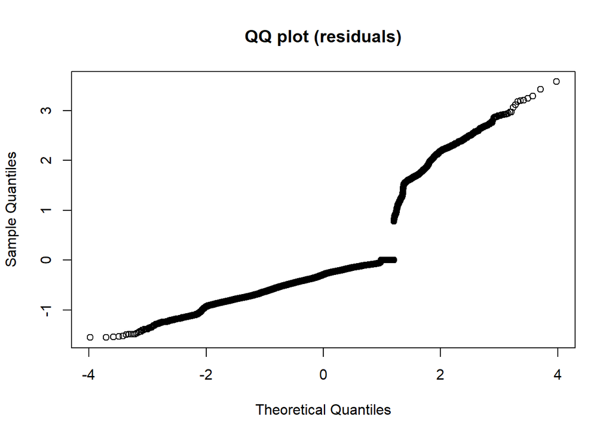

```r
# P-value is large, so don't reject null hypothesis for our second model

# Both models pass our goodness-of-fit test!

# Q-Q PLOT OF RESIDUALS

qqnorm(residuals(first_mod), main = "QQ plot (residuals)")
```

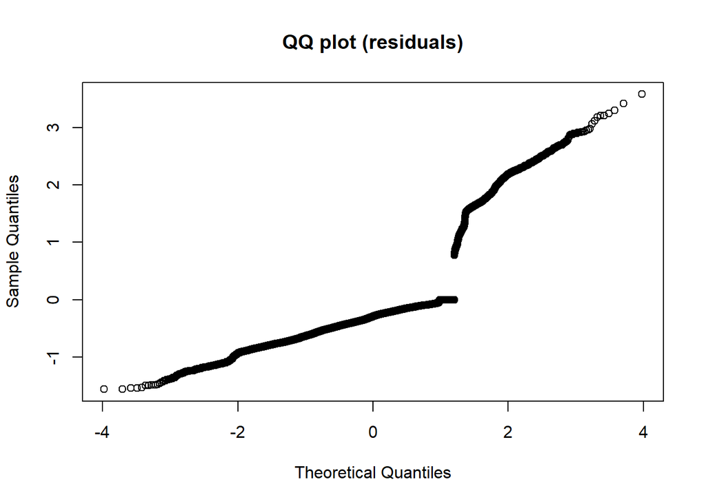

```r
qqnorm(residuals(second_mod), main = "QQ plot (residuals)")
```

```r
# Hmm, both Q-Q plots show sharp breaks in the middle, but not an issue for binary data

# CHECK WHETHER VARIATION IS ACCOUNTED FOR USING HOSMER-LEMESHOW

logitgof(crabdat$PARASITE_CODE, fitted(first_mod), g = 10)
```

```
##
##  Hosmer and Lemeshow test (binary model)
##
## data:  crabdat$PARASITE_CODE, fitted(first_mod)
## X-squared = 52.459, df = 8, p-value = 1.372e-08
```

```r
logitgof(crabdat$PARASITE_CODE, fitted(second_mod), g = 10)
```

```
##
##  Hosmer and Lemeshow test (binary model)
##
## data:  crabdat$PARASITE_CODE, fitted(second_mod)
## X-squared = 48.065, df = 8, p-value = 9.601e-08
```

```r
# In both cases, looks like we DO have variation that isn't accounted for, indicating we're missing parameters in our model. Disappointing, but we included all possible parameters in our model initially
```